# Su et al., (2024) - Revised

### D2 - Graph

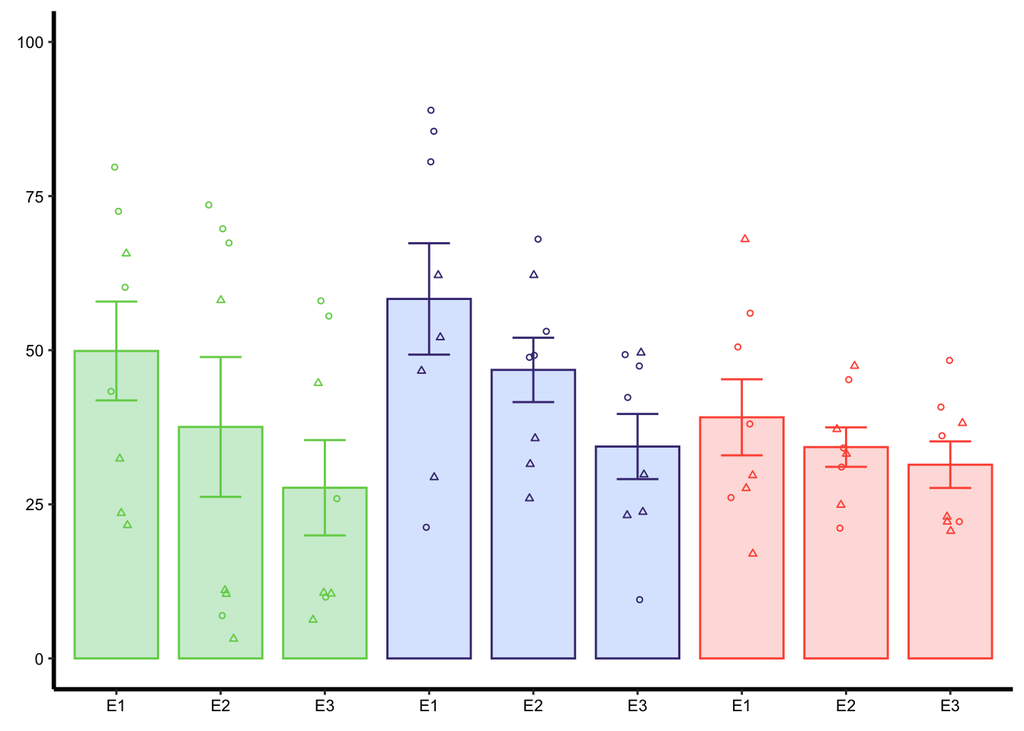

```r
Fig3.D2 <-
  ggplot(
  EXT_ave_1,
  aes(x=interaction(Exp_Type, Contingency),
      y=group_mean_freezing,
      group = Contingency,
      color = Contingency,
      fill = Contingency)) +
  scale_color_manual(values = c("10" = "#FF5743",
                                "50" = "#453781FF",
                                "100" = "#73D055FF")) +
  geom_bar(stat = "identity", alpha=0.25, width = 0.8) +
  geom_errorbar(aes(ymin = group_mean_freezing-se, ymax = group_mean_freezing+se), width=0.4) +
  geom_point(
    data=EXT_id_1,
    aes(x=interaction(Exp_Type, Contingency), y=mean_freezing, shape=Sex),
    position = position_jitterdodge(jitter.height=0, jitter.width=0.25,
                                    dodge.width = 0.8),
    size=1) +
    scale_shape(solid = FALSE) +
  scale_x_discrete(limits=c("E1.100", "E2.100", "E3.100",
                            "E1.50", "E2.50", "E3.50",
                            "E1.10", "E2.10", "E3.10"),
                   labels=c("E1", "E2", "E3", "E1", "E2", "E3", "E1", "E2", "E3")) +
  ylim(0,100) +
  labs(
    x = "CS Time",
    y = "% Time Freezing") +
  theme_bw() +
  theme(
        legend.position = "none",
        strip.background = element_blank(),
        strip.text = element_blank(),
        panel.border= element_blank(),
        plot.background = element_blank(),
        plot.title = element_text(size = 18,face="bold.italic", hjust=0.5),
        panel.grid.major = element_blank(),
        panel.grid.minor = element_blank(),
        axis.text.x = element_text(size = 8, color="black"),
        axis.text.y = element_text(size = 8, color="black"),
        axis.title.x = element_text(size = 0, face= "bold"),
        axis.title.y = element_text(size = 0, face="bold"),
        axis.line.x = element_line(color="black", linewidth = 1),
        axis.line.y = element_line(color="black", linewidth = 1))

Fig3.D2
```

```r
 #ggsave("Fig3.D2.pdf", plot = Fig3.D2, width = 2, height = 2, units = "in")
```

### D2 - Stats

```r
m3.d2.FE <- EXT_id_1 %>%
  aov_ez(id = "id",
         dv = "mean_freezing",
         between = c("Contingency"),
         within = c("Exp_Type"),
         data = .)
```

```
## Converting to factor: Contingency
```

```
## Contrasts set to contr.sum for the following variables: Contingency
```

```r
#ANOVA table
nice_m3.d2.FE <-nice(m3.d2.FE)
kable(nice_m3.d2.FE, caption = '<b>Figure 1.D2: Between-session FE, Main FX</b>') %>%
  kable_styling(bootstrap_options = "striped", full_width = F, position = "left")
```

**Figure 1.D2: Between-session FE, Main FX**

| Effect | df | MSE | F | ges | p.value |
| --- | --- | --- | --- | --- | --- |
| Contingency | 2, 21 | 902.00 | 0.94 | .063 | .408 |
| Exp_Type | 1.61, 33.71 | 188.78 | 12.76 *** | .133 | <.001 |
| Contingency:Exp_Type | 3.21, 33.71 | 188.78 | 1.07 | .025 | .380 |

```r
#Post-hoc analyses
n3.d2 <- emmeans(m3.d2.FE, ~ Exp_Type)

#Simple contrasts for Extinction Day
n3.d2_pairs <- pairs(n3.d2, simple="each")
kable(n3.d2_pairs[1], caption = '<b>Figure 1.D2-E1:Simple Contrasts by FE Day</b>')
```

**Figure 1.D2-E1:Simple Contrasts by FE Day**

| contrast | estimate | SE | df | t.ratio | p.value |
| --- | --- | --- | --- | --- | --- |
| E1 - E2 | 9.555035 | 3.321942 | 21 | 2.876340 | 0.0235423 |
| E1 - E3 | 17.939028 | 4.320484 | 21 | 4.152087 | 0.0012597 |
| E2 - E3 | 8.383993 | 2.859560 | 21 | 2.931917 | 0.0208527 |

## E. Extinction Recall ————————————————————-

Extinction recall was measured at recent (48 h) or remote (30 d) timepoints. Mice were returned to Context B and received a tone test (4 CS presentations) 48 hours and 30 days after the last day of extinction training. In addition to comparing experimental groups at each time point, we also compared percent time freezing within-subjects between the recent and remote time points to assess the level of spontaneous recovery, or the return of conditioned fear with the passage of time

### E - Dataframe

```r
ER_id_1 <- df %>%
  filter(str_detect(Component.Name, "pre-tone|post-tone", negate = TRUE),
         str_detect(Exp_Type, "ER")) %>%
  group_by(id, Sex, Contingency, Exp_Type) %>%
  summarize(mean_freezing=mean(Pct.Component.Time.Freezing), n=n(),
            se=sd(Pct.Component.Time.Freezing/sqrt(n())))
ER_ave_1 <- ER_id_1 %>%
  group_by(Contingency, Exp_Type) %>%
  summarize(group_mean_freezing=mean(mean_freezing), n=n(),
            se=sd(mean_freezing/sqrt(n())))
SR_id_1 <- df %>%
  filter(str_detect(Component.Name, "pre-tone|post-tone", negate = TRUE),
         str_detect(Exp_Type, "SR")) %>%
  group_by(id, Sex, Contingency, Exp_Type) %>%
  summarize(mean_freezing=mean(Pct.Component.Time.Freezing), n=n(),
            se=sd(Pct.Component.Time.Freezing/sqrt(n())))
SR_ave_1 <- SR_id_1 %>%
  group_by(Contingency, Exp_Type) %>%
  summarize(group_mean_freezing=mean(mean_freezing), n=n(),
            se=sd(mean_freezing/sqrt(n())))
ER_SR_id_1 <-rbind(ER_id_1, SR_id_1)
ER_SR_ave_1 <-rbind(ER_ave_1, SR_ave_1)
```

### E - Graph

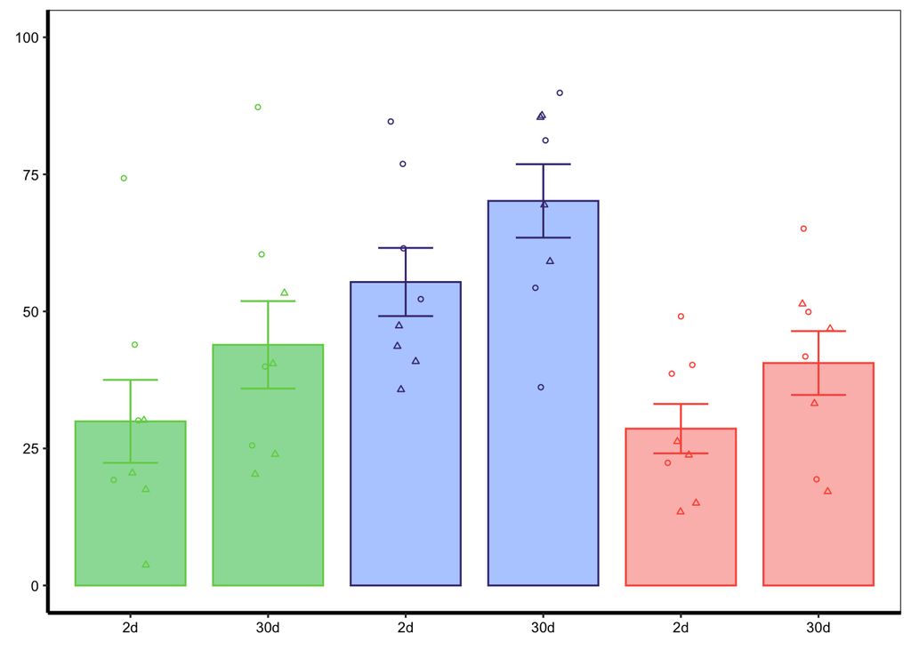

```r
Fig3E <-
  ggplot(
  ER_SR_ave_1,
  aes(x=interaction(Exp_Type, Contingency),
      y=group_mean_freezing,
      group = Contingency,
      color = Contingency,
      fill = Contingency)) +
  scale_color_manual(values = c("10" = "#FF5743",
                                "50" = "#453781FF",
                                "100" = "#73D055FF")) +
  geom_bar(stat = "identity", alpha=0.5, width = 0.8) +
  geom_errorbar(aes(ymin = group_mean_freezing-se, ymax = group_mean_freezing+se), width=0.4) +
  geom_point(
    data=ER_SR_id_1,
    aes(x=interaction(Exp_Type, Contingency), y=mean_freezing, shape=Sex),
    position = position_jitterdodge(jitter.height=0, jitter.width=0.25,
                                    dodge.width = 0.8),
    size=1 ) +
  scale_shape(solid = FALSE) +
  scale_x_discrete(limits= c("ER.100", "SR.100",
                             "ER.50", "SR.50",
                              "ER.10", "SR.10"),
                  labels= c("2d", "30d", "2d", "30d", "2d", "30d")) +
  ylim(0,100) +
  labs(x = "Day", y = "% Time Freezing") +
  theme_bw() +
  theme(
        legend.position = "none",
        strip.background = element_blank(),
        strip.text = element_blank(),
        plot.background = element_blank(),
        plot.title = element_text(size = 18,face="bold.italic", hjust=0.5),
        panel.grid.major = element_blank(),
        panel.grid.minor = element_blank(),
        axis.text.x = element_text(size = 8, color="black"),
        axis.text.y = element_text(size = 8, color="black"),
        axis.title.x = element_text(size = 0, face= "bold"),
        axis.title.y = element_text(size = 0, face="bold"),
        axis.line.x = element_line(color="black", linewidth = 1),
        axis.line.y = element_line(color="black", linewidth = 1)) +
  labs(
    x = "CS Time",
    y = "% Time Freezing")

Fig3E
```

```r
#ggsave("Fig3E.pdf", plot = Fig3E, width = 2, height = 2, units = "in")
```

### E - Stats

```r
m2e <- ER_SR_id_1 %>%
  aov_ez(id = "id",
         dv = "mean_freezing",
         between = "Contingency",
         within = "Exp_Type",
         data = .)
```

```
## Converting to factor: Contingency
```

```
## Contrasts set to contr.sum for the following variables: Contingency
```

```r
nice_m2e<- nice(m2e)

kable(nice_m2e, caption = '<b>Figure 2E: FE recall Main FX</b>') %>%
  kable_styling(bootstrap_options = "striped", full_width = F, position = "left")
```

**Figure 2E: FE recall Main FX**

| Effect | df | MSE | F | ges | p.value |
| --- | --- | --- | --- | --- | --- |
| Contingency | 2, 21 | 345.52 | 11.31 *** | .351 | <.001 |
| Exp_Type | 1, 21 | 344.32 | 6.42 * | .132 | .019 |
| Contingency:Exp_Type | 2, 21 | 344.32 | 0.02 | .001 | .976 |

```r
#Post-hoc analyses
#Contrast for Contingency
n2e.1 <- emmeans(m2e, ~ Contingency)
n2e.1_pairs<- pairs(n2e.1, simple="each")

kable(n2e.1_pairs[1], caption = '<b>Figure 2B-2: Simple contrasts for Contingency</b>')
```

**Figure 2B-2: Simple contrasts for Contingency**

| contrast | estimate | SE | df | t.ratio | p.value |
| --- | --- | --- | --- | --- | --- |
| Contingency10 - Contingency100 | -2.321875 | 6.571941 | 21 | -0.3533013 | 0.9337246 |
| Contingency10 - Contingency50 | -28.159531 | 6.571941 | 21 | -4.2848122 | 0.0009208 |
| Contingency100 - Contingency50 | -25.837656 | 6.571941 | 21 | -3.9315109 | 0.0021179 |

```r
#Contrast for Recall test day
n2e.2 <- emmeans(m2e, ~ Exp_Type)
n2e.2_pairs<- pairs(n2e.2, simple="each")

kable(n2e.2_pairs[1], caption = '<b>Figure 2B-2: Simple contrasts for Tone-test day</b>')
```

**Figure 2B-2: Simple contrasts for Tone-test day**

| contrast | estimate | SE | df | t.ratio | p.value |
| --- | --- | --- | --- | --- | --- |
| ER - SR | -13.5751 | 5.356648 | 21 | -2.534254 | 0.0192927 |

## END Fig 3

```r
rm(list=(ls()))
```

# Fig 4 B-C: Reducing the number of Fear Conditioning Sessions to 1

Previous studies have found that the over-training may occlude the PREE (Hilton 1969; Sutherland et al. 1965). To address the possibility that this was occuring in our experiments, we reduced the cued-fear conditioning protocol from two days to one (see Fig. 4A). As in Fig. 1-2, mice were conditioned using 3 (100%) or 6 (50%) CS which were paired with 3 US (0.75 mA). All statistical analyses and graphing were performed as in Fig. 1-2.

## Load and tidy data

Data was exported from VideoFreeze as CSV files. The header rows of the raw CSV files contain information regarding how the data was exported (ie how data was segmented into bins as well as what motion index threshold was used as a cut-off for assessing freezing).

```r
# df ---------------------------------------------------

# Create a vector with each filename from all the CSVs in the home directory,
list.filenames <- list.files("./Fig4_BC", pattern = ".csv$",
                             full.names=TRUE, recursive = TRUE)

# These vectors will be used to create 3CS binned averages
bin1 =c("tone 01", "tone 02", "tone 03")
bin2 =c("tone 04", "tone 05", "tone 06")
bin3 =c("tone 07", "tone 08", "tone 09")
bin4 =c("tone 10", "tone 11", "tone 12")

list.data <- list()

for (i in 1:length(list.filenames)) {
  list.data[[i]] <- read.csv(list.filenames[[i]], skip=
                               ifelse(str_detect(list.filenames[[i]], "FC\\w*100.csv$"), 15,
                                      ifelse(str_detect(list.filenames[[i]], "FC\\w*50.csv$"), 18,
                                                    ifelse(str_detect(list.filenames[[i]], "E1"), 24,
                                                           ifelse(str_detect(list.filenames[[i]], "SR"), 16,
                                                                  24))))
  )
  list.data[[i]]$ExpDetails <- str_sub(list.filenames[[i]], 30, -5)

}

list.data <- list.data %>%
  reduce(full_join) %>%  #collapse separate items in list into one
  filter(Trial != "NA") %>% #remove empty rows
  separate(col=Animal, into = c("Strain", "Sex", "Cage", "Animal"), sep = "-") %>% # separate existing columns as indicated below
  separate(col=Group, into = c("CS_num", "Contingency", "CS_dur", "FE_context"), sep = "-") %>%
  separate(col=ExpDetails, into = c("Date", "Exp_Type", "Unused"), sep="_") %>%
  mutate(
    id = paste(Strain, Sex, Cage, Animal, sep="_"), #add a column with an animal ID
    CS= ifelse(str_detect(Exp_Type, "FC") & Contingency == "100", Component.Name,
         ifelse(str_detect(Exp_Type, "FC") & Contingency == "50" & Component.Name == "tone 01", "tone 01",
          ifelse(str_detect(Exp_Type, "FC") & Contingency == "50" & Component.Name == "tone 03", "tone 02",
           ifelse(str_detect(Exp_Type, "FC") & Contingency == "50" & Component.Name == "tone 06", "tone 03",

         ifelse(str_detect(Exp_Type, "FC") & Contingency == "10" & Component.Name == "tone 01", "tone 01",
            ifelse(str_detect(Exp_Type, "FC") & Contingency == "10" & Component.Name == "tone 23", "tone 02",
                ifelse(str_detect(Exp_Type, "FC") & Contingency == "10" & Component.Name == "tone 25", "tone 03",

                           ifelse(str_detect(Exp_Type, "FC", negate=TRUE), Component.Name, NA

                                           )))))))),

      Bin = ifelse(Component.Name %in% "pre-tone", "Pre",
                   ifelse(Component.Name %in% bin1, "1",
                         ifelse(Component.Name %in% bin2, "2",
                                ifelse(Component.Name %in% bin3, "3",
                                       ifelse(Component.Name %in% bin4, "4", "Post")))))
  )
```

[output not shown]

```r
# Conver list into a dataframe
df<-as.data.frame(list.data)

df<-as.data.frame(list.data) %>% #Convert list into a dataframe
  relocate(20:25, .after = 12) #Move columns containing metadata such that they precede data

#The code below removes animals whose freezing on FC2 was below 15% time freezing, this was done since the focus of the study is on extinction
Remove <- df %>% #Create a dataframe  with only the animals whose FC2 freezing was below 15%
  filter(Exp_Type== "FC2") %>%
  group_by(id)%>%
  summarise(mean_FC2_freezing = mean(Pct.Component.Time.Freezing)) %>%
  filter(mean_FC2_freezing < 15)

Remove <- unlist(Remove$id) #keep only the list of animals (as a vector)

`%notin%` <- Negate(`%in%`) #Function for negating the %in% function (source: https://www.r-bloggers.com/2018/07/the-notin-operator/)

df <- df %>%
  filter(id %notin% Remove) #filter for animals not in the Remove vector (i.e. filtering for animals freezing more than 15% on FC2)

rm(list=setdiff(ls(), "df")) #remove everything from environment except the df
df<- df %>%
  drop_na(Trial, Strain, Experiment)
```

## B1. Within-sessopm FC

### B1 - Dataframe

```r
#Create a dataframe with averages for each animal for each CS
FC_id_1.1 <- df %>%
  filter(str_detect(Exp_Type, "FC")) %>%
  group_by(id, Contingency, Sex, Component.Name, Exp_Type, CS) %>%
  summarize(mean_freezing=mean(Pct.Component.Time.Freezing), n=n())
```

```
## 'Component.Name', 'Exp_Type'. You can override using the `.groups` argument.
```

```r
#Create a dataframe with averages for each experimental group for each CS
FC_ave_1.1 <- FC_id_1.1 %>%
  group_by(Contingency,Component.Name, Exp_Type) %>%
  summarize(group_mean_freezing=mean(mean_freezing), n=n(),
            se=sd(mean_freezing/sqrt(n())))
```

### B1 - Graph

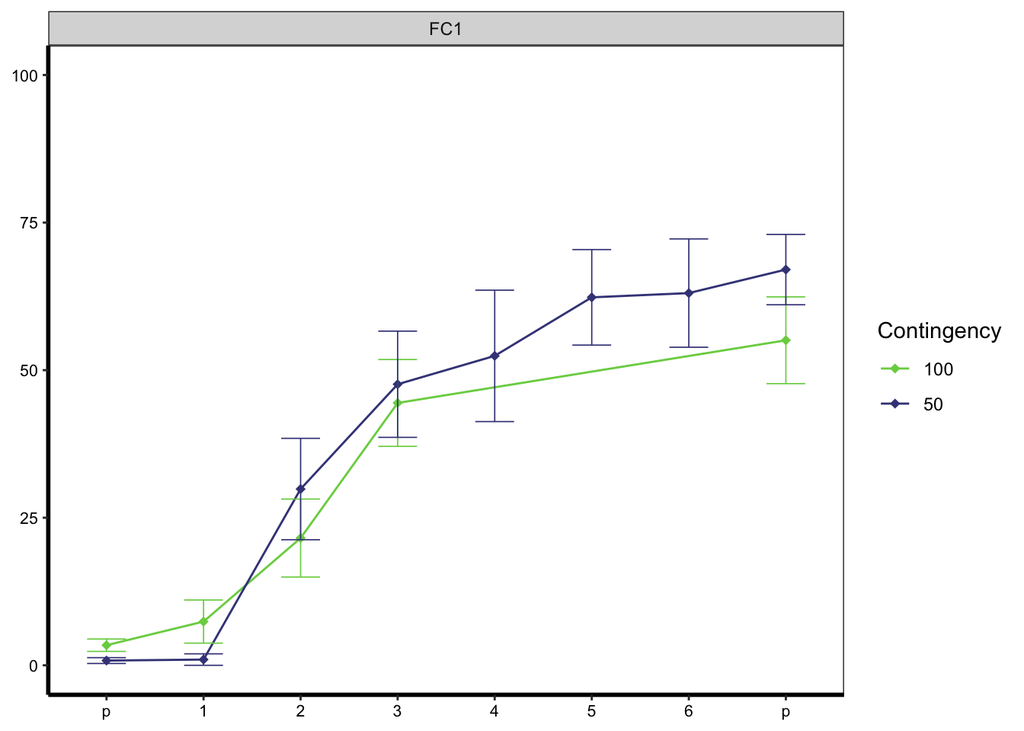

```r
Fig4.B1 <-
  ggplot(FC_ave_1.1, aes(x=interaction(Component.Name), y=group_mean_freezing, group=Contingency, color=Contingency)) +
  scale_fill_viridis(discrete = TRUE, begin=0.8, end=0.2) +
  scale_colour_viridis(discrete = TRUE, begin=0.8, end=0.2) +
  facet_wrap(~Exp_Type) +
  geom_line() +
  geom_point(shape=18, size=2) +
  geom_errorbar(aes(ymin = group_mean_freezing-se, ymax = group_mean_freezing+se, width = 0.4), linewidth=0.3) +
  ylim(0,100) +
  scale_x_discrete(limits=c("pre-tone",
                            "tone 01", "tone 02", "tone 03",  "tone 04", "tone 05",
                            "tone 06",
                            "post-tone"),
                   labels=c("p",
                            "1", "2", "3", "4", "5",
                            "6",
                            "p")) +
  labs(
    x = "CS Time",
    y = "% Time Freezing") +
  theme_bw() +
  theme(
        # legend.position = "none",
        # strip.background = element_blank(),
        # strip.text.x = element_blank(),
        plot.background = element_blank(),
        plot.title = element_blank(),
        panel.grid.major = element_blank(),
        panel.grid.minor = element_blank(),
        axis.text.x = element_text(size = 8, color="black"),
        axis.text.y = element_text(size = 8, color="black"),
        axis.title.x = element_blank(),
        axis.title.y = element_blank(),
        axis.line.x = element_line(color="black", linewidth = 1),
        axis.line.y = element_line(color="black", linewidth = 1))

Fig4.B1
```

```r
 #ggsave("Fig4B1.pdf", plot = Fig4.B1, width = 1.25, height = 2, units = "in")
```

### B1 - Stats

Sex was originally in the statistical model: mean_freezing ~ Contingency (2) X CS_time (2) X Sex (2). However, considering broad lack of sex-specific effects, it was dropped from models.

```r
# Analysis of FC1 Data
m4b1_FC1 <- FC_id_1.1  %>%
   filter(str_detect(CS, "tone 01|tone 02|tone 03") &
          Exp_Type == "FC1")  %>%
  aov_ez(id = "id",
         dv = "mean_freezing",
         between = c("Contingency"),
         within = c("CS"),
         data = .)
```

```
## Converting to factor: Contingency
```

```
## Contrasts set to contr.sum for the following variables: Contingency
```

```r
#ANOVA table
nice_m4b1_FC1 <-nice(m4b1_FC1)
kable(nice_m4b1_FC1, caption = '<b>Figure 4.B1: Main FX</b>') %>%
  kable_styling(bootstrap_options = "striped", full_width = F, position = "left")
```

**Figure 4.B1: Main FX**

| Effect | df | MSE | F | ges | p.value |
| --- | --- | --- | --- | --- | --- |
| Contingency | 1, 19 | 670.90 | 3.73 + | .077 | .068 |
| CS | 1.99, 37.84 | 453.92 | 28.43 *** | .462 | <.001 |
| Contingency:CS | 1.99, 37.84 | 453.92 | 3.30 * | .091 | .048 |

```r
#Post-hoc analyses
n4b1.1_FC1 <- emmeans(m4b1_FC1, ~ Contingency * CS)
n4b1.1_pairs_FC1<- pairs(n4b1.1_FC1, simple="each")
kable(n4b1.1_pairs_FC1[1], caption = '<b>Figure 4.B1: Simple contrasts for Contingency</b>')
```

**Figure 4.B1: Simple contrasts for Contingency**

| contrast | CS | estimate | SE | df | t.ratio | p.value |
| --- | --- | --- | --- | --- | --- | --- |
| Contingency100 - Contingency50 | tone.01 | 6.435278 | 3.33422 | 19 | 1.930070 | 0.0686640 |
| Contingency100 - Contingency50 | tone.02 | -26.055278 | 11.89503 | 19 | -2.190434 | 0.0411668 |
| Contingency100 - Contingency50 | tone.03 | -18.611389 | 12.39359 | 19 | -1.501695 | 0.1496133 |

```r
kable(n4b1.1_pairs_FC1[2], caption = '<b>Figure 4.B1: Simple contrasts for CS</b>')
```

**Figure 4.B1: Simple contrasts for CS**

| contrast | Contingency | estimate | SE | df | t.ratio | p.value |
| --- | --- | --- | --- | --- | --- | --- |
| tone.01 - tone.02 | 100 | -14.14778 | 9.804178 | 19 | -1.443035 | 0.3397674 |
| tone.01 - tone.03 | 100 | -37.03667 | 9.911037 | 19 | -3.736911 | 0.0038084 |
| tone.02 - tone.03 | 100 | -22.88889 | 10.341542 | 19 | -2.213296 | 0.0944878 |
| tone.01 - tone.02 | 50 | -46.63833 | 8.490668 | 19 | -5.492894 | 0.0000762 |
| tone.01 - tone.03 | 50 | -62.08333 | 8.583210 | 19 | -7.233114 | 0.0000021 |
| tone.02 - tone.03 | 50 | -15.44500 | 8.956038 | 19 | -1.724535 | 0.2221023 |

## B2 - Between-session FC

### B2 - Dataframe

```r
#Create a dataframe with CS freezing averaged for each experimental group
FC_id_1.2 <- FC_id_1.1 %>%
  filter(str_detect(Component.Name, "tone 01|pre-tone|post-tone", negate=TRUE)) %>%
  group_by(id, Sex, Contingency, Exp_Type) %>%
  summarize(mean_freezing=mean(mean_freezing), n=n(),
            se=sd(mean_freezing/sqrt(n())))
FC_ave_1.2 <- FC_id_1.2 %>%
  group_by(Contingency, Exp_Type) %>%
  summarize(group_mean_freezing=mean(mean_freezing), n=n(),
            se=sd(mean_freezing/sqrt(n())))
```

### B2 - Graph

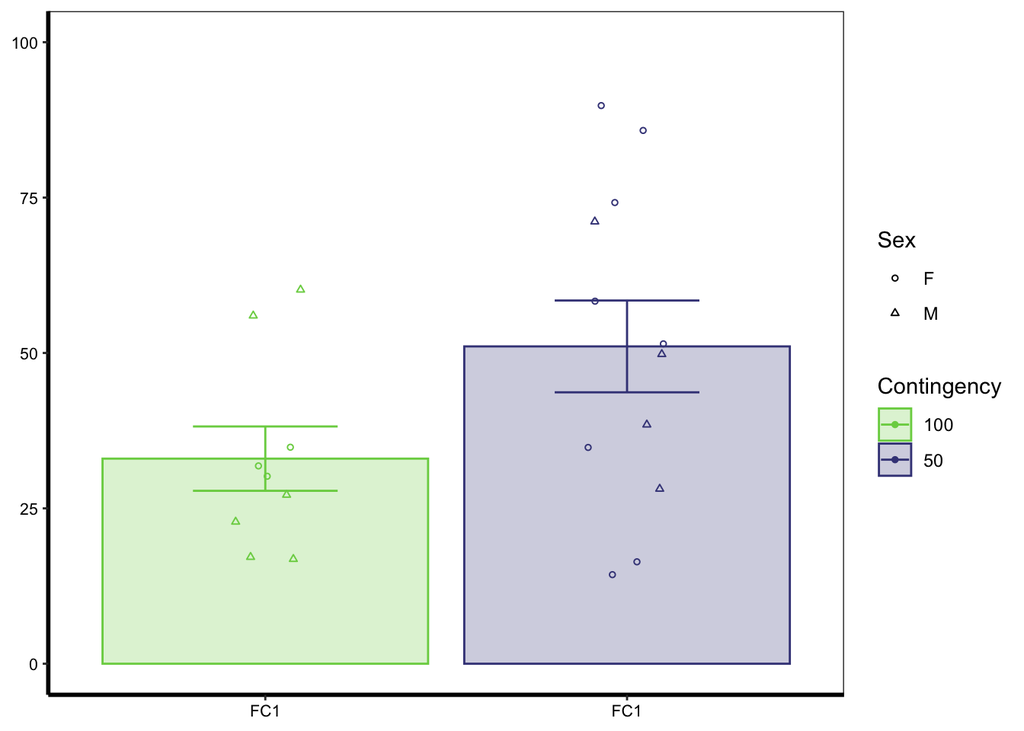

```r
Fig4.B2 <- ggplot(FC_ave_1.2,
  aes(x=interaction(Exp_Type,Contingency),
      y=group_mean_freezing,
      group = Contingency, fill= Contingency, color=Contingency)) +
  scale_fill_viridis(discrete = TRUE, begin=0.8, end=0.2) +
  scale_colour_viridis(discrete = TRUE, begin=0.8, end=0.2) +
  geom_errorbar(aes(ymin = group_mean_freezing-se, ymax = group_mean_freezing+se), width=0.4) +
  geom_bar(stat="identity", alpha=0.25) +
  geom_point(
    data=FC_id_1.2,
    aes(x=interaction(Exp_Type, Contingency), y=mean_freezing, shape=Sex),position = position_jitterdodge(jitter.height=0, jitter.width=0.25, dodge.width = 0.8), size=1) +
  scale_shape(solid = FALSE) +
   scale_x_discrete(limits=c("FC1.100","FC1.50"),
                    labels= c("FC1", "FC1")) +
  ylim(0,100) +
  theme_bw() +
  theme(
        # legend.position = "none",
        # strip.background = element_blank(),
        # strip.text = element_blank(),
        plot.background = element_blank(),
        axis.title.x = element_blank(),
        axis.title.y = element_blank(),
        plot.title = element_blank(),
        panel.grid.major = element_blank(),
        panel.grid.minor = element_blank(),
        axis.text.x = element_text(size = 8, color="black"),
        axis.text.y = element_text(size = 8, color="black"),
        axis.line.x = element_line(color="black", linewidth = 1),
        axis.line.y = element_line(color="black", linewidth = 1))+
  labs(
    x = "CS Time",
    y = "% Time Freezing")

Fig4.B2
```

```r
  #ggsave("Fig4B2.pdf", plot = Fig4.B2, width = 1, height = 2, units = "in")
```

### B2 - Stats

```r
m4b2 <- FC_id_1.2 %>%
  aov_ez(id = "id",
         dv = "mean_freezing",
         between = c("Contingency"),
         within = c("Exp_Type"),
         data = .)
```

```
## Converting to factor: Contingency
```

```
## Contrasts set to contr.sum for the following variables: Contingency
```

```r
#ANOVA table
nice_m4b2  <-nice(m4b2)
kable(nice_m4b2, caption = '<b>Figure 4.B2: Main FX</b>') %>%
  kable_styling(bootstrap_options = "striped", full_width = F, position = "left")
```

**Figure 4.B2: Main FX**

| Effect | df | MSE | F | ges | p.value |
| --- | --- | --- | --- | --- | --- |
| Contingency | 1, 19 | 480.48 | 3.49 + | .155 | .077 |

## C. Extinction acquisition———————————————–

### C - Dataframe

```r
EXT_bin_id_1 <- df %>%
  filter(str_detect(Exp_Type, "E"),
         str_detect(Experiment, "ER", negate = TRUE)) %>%
  group_by(Exp_Type, id, Sex, Contingency, Bin) %>%
  summarize(mean_freezing=mean(Pct.Component.Time.Freezing), n=n(),
            se=sd(Pct.Component.Time.Freezing/sqrt(n())))
```

```
## can override using the `.groups` argument.
```

```r
EXT_bin_ave_1 <- EXT_bin_id_1 %>%
  group_by(Exp_Type, Bin, Contingency) %>%
  summarize(group_mean_freezing=mean(mean_freezing), n=n(),
            se=sd(mean_freezing/sqrt(n())))
EXT_bin_ave_1$Bin <- factor(EXT_bin_ave_1$Bin, levels = c("Pre", "1", "2", "3", "4", "Post"))
```

### C - Graph

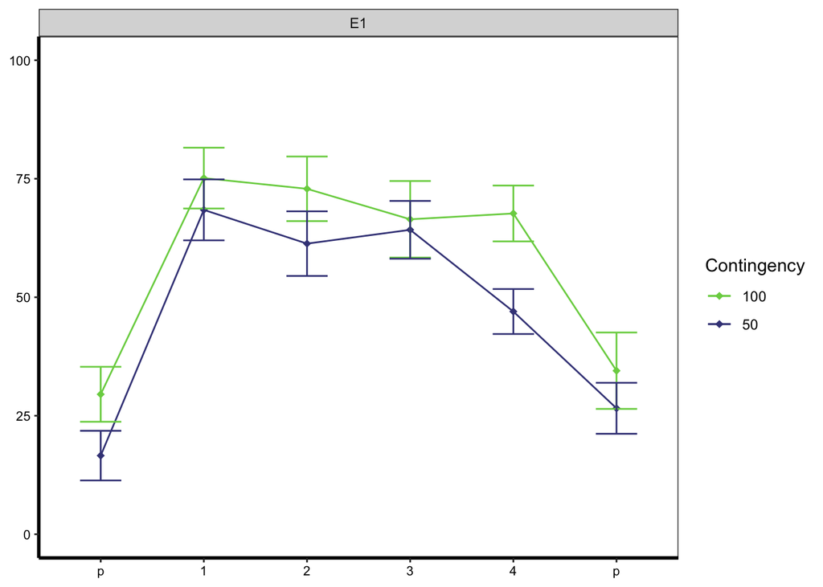

```r
Fig4D.1 <-
  ggplot(
  data = subset(EXT_bin_ave_1, !is.na(Bin)),
  aes(x=interaction(Bin),
      y=group_mean_freezing,
      group = Contingency, color= Contingency, fill=Contingency)) +
  scale_fill_viridis(discrete = TRUE, begin=0.8, end=0.2) +
  scale_colour_viridis(discrete = TRUE, begin=0.8, end=0.2) +
  facet_wrap(~Exp_Type) +
  geom_line() +
  geom_point(shape=18, size=2) +
  scale_shape(solid = FALSE) +
  geom_errorbar(aes(ymin = group_mean_freezing-se, ymax = group_mean_freezing+se), width=0.4) +
  scale_x_discrete(limits=c("Pre", "1", "2", "3", "4", "Post"),
                   labels=c("p", "1", "2", "3", "4", "p")) +
  ylim(0,100) +
  labs(x = "Bin", y = "% Time Freezing") +
  theme_bw() +
   theme(
        # legend.position = "none",
        # strip.background = element_blank(),
        # strip.text = element_blank(),
        plot.background = element_blank(),
        plot.title = element_blank(),
        panel.grid.major = element_blank(),
        panel.grid.minor = element_blank(),
        axis.text.x = element_text(size = 8, color="black"),
        axis.text.y = element_text(size = 8, color="black"),
        axis.title.x = element_blank(),
        axis.title.y = element_blank(),
        axis.line.x = element_line(color="black", linewidth = 1),
        axis.line.y = element_line(color="black", linewidth = 1))

Fig4D.1
```

```r
#ggsave("Fig4D1.pdf", plot = Fig4D.1, width = 1.25, height = 2, units = "in")
```

### C - Stats

```r
#FE1 - Mean freezing analysis

m4.d1.FE1 <- EXT_bin_id_1 %>%
  filter(str_detect(Bin, "Pre|Post", negate = TRUE)) %>%
   filter(Exp_Type == "E1") %>%
  aov_ez(id = "id",
         dv = "mean_freezing",
         between = c("Contingency"),
         within = c("Bin"),
         data = .)
```

```
## Converting to factor: Contingency
```

```
## Contrasts set to contr.sum for the following variables: Contingency
```

```r
##ANOVA table
nice_m4.d1.FE1 <-nice(m4.d1.FE1)
kable(nice_m4.d1.FE1, caption = '<b>Figure 4.D1-E1: Main FX</b>') %>%
  kable_styling(bootstrap_options = "striped", full_width = F, position = "left")
```

**Figure 4.D1-E1: Main FX**

| Effect | df | MSE | F | ges | p.value |
| --- | --- | --- | --- | --- | --- |
| Contingency | 1, 19 | 1092.37 | 1.99 | .062 | .174 |
| Bin | 2.71, 51.51 | 236.96 | 3.48 * | .064 | .026 |
| Contingency:Bin | 2.71, 51.51 | 236.96 | 1.50 | .028 | .227 |

```r
##Post-hoc analyses
n4.d1.FE1 <- emmeans(m4.d1.FE1, ~ Bin)
n4.d1.FE1_pairs<- pairs(n4.d1.FE1, simple="each")

##Simple contrasts for Bin
kable(n4.d1.FE1_pairs[1], caption = '<b>Figure 4.D1-E1: Simple Contrasts by CS bin</b>')
```

**Figure 4.D1-E1: Simple Contrasts by CS bin**

| contrast | estimate | SE | df | t.ratio | p.value |
| --- | --- | --- | --- | --- | --- |
| X1 - X2 | 4.690787 | 4.164746 | 19 | 1.126308 | 0.6782908 |
| X1 - X3 | 6.449630 | 4.041055 | 19 | 1.596026 | 0.4042547 |
| X1 - X4 | 14.452361 | 4.320856 | 19 | 3.344791 | 0.0164204 |
| X2 - X3 | 1.758843 | 5.303102 | 19 | 0.331663 | 0.9870169 |
| X2 - X4 | 9.761574 | 5.024031 | 19 | 1.942976 | 0.2441071 |
| X3 - X4 | 8.002731 | 4.383689 | 19 | 1.825570 | 0.2925170 |

#### FE Linear contrasts (i.e. contrast for slopes)

We expressed the contrast in units that represent the slope of the best-fitting line in the relationship between the dependent (freezing) and independent variables. Note to linear regression users: this slope is identical to the one we would find using linear regression. A linear regression model is nothing more than a linear contrast.

```r
#Weights for FE-CS
FE_dm = mean(c(1:12)) - c(1:12) #Demeaned CSs
FE_dm_ss = sum((FE_dm)^2) #Sum of squares of demeaned CSs
weightsFE = FE_dm/FE_dm_ss #Standardized CS scores
weightsFE
```

```
##  [1]  0.038461538  0.031468531  0.024475524  0.017482517  0.010489510
##  [6]  0.003496503 -0.003496503 -0.010489510 -0.017482517 -0.024475524
## [11] -0.031468531 -0.038461538
```

```r
# Creating dataframe for slope analysis
EXT_weighted_id_2 <- df %>%
  filter(str_detect(Component.Name, "pre-tone|post-tone", negate = TRUE),
         str_detect(Exp_Type, "E"),
         str_detect(Exp_Type, "ER", negate = TRUE))

EXT_weighted_id_2$weights <- weightsFE

EXT_weighted_id_2 <- EXT_weighted_id_2 %>%
  mutate(weighted_FE = weights * Pct.Component.Time.Freezing)

Ext_slope.2 <- EXT_weighted_id_2 %>%
  group_by(id, Contingency, CS_dur, Exp_Type) %>%
  summarise(slope= sum(weighted_FE))
### E1
m4.slope.FE1 <- Ext_slope.2 %>%
   filter(Exp_Type == "E1") %>%
  aov_ez(id = "id",
         dv = "slope",
         between = c("Contingency"),
         data = .)
```

```
## Converting to factor: Contingency
## Contrasts set to contr.sum for the following variables: Contingency
```

```r
##ANOVA table
nice_m4.slope.FE1 <-nice(m4.slope.FE1)
kable(nice_m4.slope.FE1, caption = '<b>Figure 4.Slope-E1: Main FX</b>') %>%
  kable_styling(bootstrap_options = "striped", full_width = F, position = "left")
```

**Figure 4.Slope-E1: Main FX**

| Effect | df | MSE | F | ges | p.value |
| --- | --- | --- | --- | --- | --- |
| Contingency | 1, 19 | 4.54 | 0.99 | .050 | .332 |

## END Fig 4 B-C

```r
rm(list=(ls()))
```

# Fig 4 E-F. Testing effect of interpolated extinction on FE

Finally, we attempted to stimulate a PREE using an interpolated extinction (IPE) session (Fig. 4D). We based this approach on a previous study which inflated the PREE by interpolating a block of non-reinforced trials (20 CS) in the conditioning phase with the rationale of enhancing the effect of nonreinforcement (Hilton 1969). As shown in Fig. 4D, mice were exposed to the interpolated CS session (+IPE) on day two of the paradigm, in between FC training days (Day 1 and Day 3); mice in the control group (-IPE) were placed in the chamber for an equal amount of time but were not exposed to CS.

## Load and tidy data

Data was exported from VideoFreeze as CSV files. The header rows of the raw CSV files contain information regarding how the data was exported (ie how data was segmented into bins as well as what motion index threshold was used as a cut-off for assessing freezing).

```r
list.filenames <- list.files("./Fig4_EF", pattern = ".csv$",
                             full.names=TRUE, recursive = TRUE)

# These vectors will be used to create 3CS binned averages
bin1 =c("tone 01", "tone 02", "tone 03")
bin2 =c("tone 04", "tone 05", "tone 06")
bin3 =c("tone 07", "tone 08", "tone 09")
bin4 =c("tone 10", "tone 11", "tone 12")

# delete the metadata from the list.filenames
list.data <- list()

for (i in 1:length(list.filenames)) {
  list.data[[i]] <- read.csv(list.filenames[[i]], skip=
                               ifelse(str_detect(list.filenames[[i]], "FC\\w*CR.csv$"), 15,
                                      ifelse(str_detect(list.filenames[[i]], "FC\\w*PR.csv$"), 18,
                                             ifelse(str_detect(list.filenames[[i]], "IPE"), 32,
                                                    ifelse(str_detect(list.filenames[[i]], "E1"), 24,
                                                           ifelse(str_detect(list.filenames[[i]], "SR"), 16,
                                                                  24)))))
  )
  list.data[[i]]$ExpDetails <- str_sub(list.filenames[[i]], 30, -5)

}

list.data <- list.data %>%
  reduce(full_join) %>% #collapse separate items in list into one
  separate(col=ExpDetails, into = c("Exp_Date", "Exp_Type", "Exp_Room", "Exp_Sched"), sep = "_") %>%
  separate(col=Group, into = c("Contingency", "IPE"), sep = "_") %>%
  separate(col = Animal, into = c("Strain", "Sex", "Cage", "Animal"), sep = "-") %>%
   mutate(
    id = paste(Strain, Sex, Cage, Animal, sep="_"), #add a column with an animal ID
    CS= ifelse(str_detect(Exp_Type, "FC") & Contingency == "CR", Component.Name,
         ifelse(str_detect(Exp_Type, "FC") & Contingency == "PR" & Component.Name == "tone 01", "tone 01",
          ifelse(str_detect(Exp_Type, "FC") & Contingency == "PR" & Component.Name == "tone 03", "tone 02",
           ifelse(str_detect(Exp_Type, "FC") & Contingency == "PR" & Component.Name == "tone 06", "tone 03",

                           ifelse(str_detect(Exp_Type, "FC", negate=TRUE), Component.Name, NA

                                           ))))),
    Bin = ifelse(Component.Name %in% "pre-tone", "Pre",
                   ifelse(Component.Name %in% bin1, "1",
                         ifelse(Component.Name %in% bin2, "2",
                                ifelse(Component.Name %in% bin3, "3",
                                       ifelse(Component.Name %in% bin4, "4", "Post")))))
  )
```

[output not shown]

```r
# Conver list into a dataframe
df<-as.data.frame(list.data) %>% #Convert list into a dataframe
  relocate(18:24, .after = 10) %>%  #Move columns containing metadata such that they precede data
  drop_na(Trial, Strain, Experiment)

rm(list=setdiff(ls(), "df"))
# df<- df %>%
#   drop_na(Trial, Strain, Experiment)

#write_csv(df, "220803_PREE_df.csv")
```

## E1 - Within-session FC

### E1 - Dataframe

```r
FC_id_1.1 <- df %>%
  filter(str_detect(Exp_Type, "FC")) %>%
  group_by(id, Sex, Contingency, IPE, Exp_Type, Component.Name, CS) %>%
  summarize(mean_freezing=mean(Pct.Component.Time.Freezing), n=n())
```

```
## 'Exp_Type', 'Component.Name'. You can override using the `.groups` argument.
```

```r
#write_csv(FC_id, "220803_PREE_FC_id.csv")

FC_ave_1.1 <- FC_id_1.1 %>%
  group_by(Contingency, IPE, Exp_Type, Component.Name) %>%
  summarize(group_mean_freezing=mean(mean_freezing), n=n(),
            se=sd(mean_freezing/sqrt(n())))
#write_csv(FC_ave, "220803_PREE_FC_ave.csv")
```

### E1 - Graph

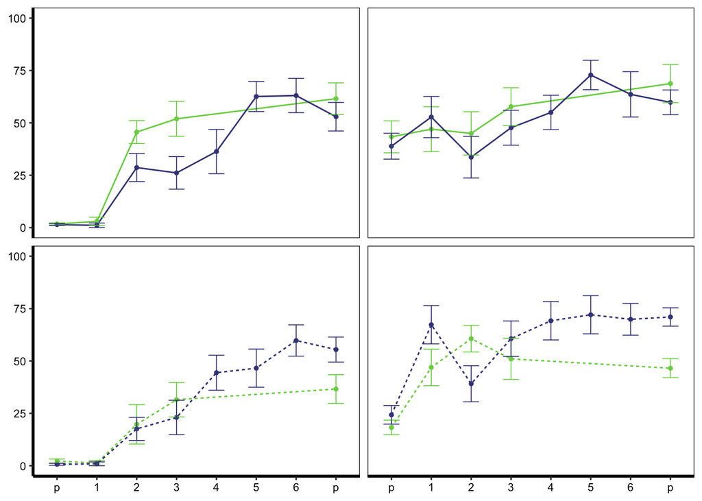

```r
Fig4E1 <-
  ggplot(FC_ave_1.1, aes(x=interaction(Component.Name), y=group_mean_freezing, group=interaction(Contingency, IPE), color=interaction(Contingency), linetype= IPE)) +
  scale_color_viridis_d(begin=0.8, end=0.2) +
  scale_fill_viridis_d(begin=0.8, end=0.2) +
  facet_wrap(~IPE*Exp_Type) +
  geom_line() +
  geom_point(size=1) +
  geom_errorbar(aes(ymin = group_mean_freezing-se, ymax = group_mean_freezing+se, width = 0.4), linewidth=0.3, linetype=1) +
  ylim(0,100) +
  scale_x_discrete(limits=c("pre-tone", "tone 01", "tone 02", "tone 03",  "tone 04", "tone 05",
                            "tone 06",
                            "post-tone"),
                   labels=c("p", "1", "2", "3", "4", "5",
                            "6",
                            "p")) +
  labs(
    x = "CS Time",
    y = "% Time Freezing") +
  theme_bw() +
  theme(
        legend.position = "none",
        strip.background = element_blank(),
        strip.text = element_blank(),
        plot.background = element_blank(),
        plot.title = element_blank(),
        panel.grid.major = element_blank(),
        panel.grid.minor = element_blank(),
        axis.text.x = element_text(size = 8, color="black"),
        axis.text.y = element_text(size = 8, color="black"),
        axis.title.x = element_blank(),
        axis.title.y = element_blank(),
        axis.line.x = element_line(color="black", linewidth = 1),
        axis.line.y = element_line(color="black", linewidth = 1))

Fig4E1
```

```r
 #ggsave("FigE1.pdf", plot = Fig4E2, width = 2, height = 2, units = "in")
```

### E1 - Stats

```r
# Analysis of FC1 Data
m4E1_FC1 <- FC_id_1.1  %>%
   filter(str_detect(CS, "tone 01|tone 02|tone 03") &
          Exp_Type == "FC1")  %>%
  aov_ez(id = "id",
         dv = "mean_freezing",
         between = c("Contingency", "IPE"),
         within = c("CS"),
         data = .)
```

```
## Converting to factor: Contingency, IPE
```

```
## Contrasts set to contr.sum for the following variables: Contingency, IPE
```

```r
#ANOVA table
nice_m4E1_FC1 <-nice(m4E1_FC1)
kable(nice_m4E1_FC1, caption = '<b>Figure 4.E1: FC1 Main FX</b>') %>%
  kable_styling(bootstrap_options = "striped", full_width = F, position = "left")
```

**Figure 4.E1: FC1 Main FX**

| Effect | df | MSE | F | ges | p.value |
| --- | --- | --- | --- | --- | --- |
| Contingency | 1, 38 | 512.80 | 0.75 | .007 | .393 |
| IPE | 1, 38 | 512.80 | 5.07 * | .048 | .030 |
| Contingency:IPE | 1, 38 | 512.80 | 2.93 + | .028 | .095 |
| CS | 1.83, 69.48 | 456.62 | 62.87 *** | .506 | <.001 |
| Contingency:CS | 1.83, 69.48 | 456.62 | 5.24 ** | .079 | .009 |
| IPE:CS | 1.83, 69.48 | 456.62 | 1.29 | .021 | .279 |
| Contingency:IPE:CS | 1.83, 69.48 | 456.62 | 0.76 | .012 | .460 |

```r
#Post-hoc analyses
n4E1.1_FC1 <- emmeans(m4E1_FC1, ~ Contingency * CS)
n4E1.1_FC1_pairs<- pairs(n4E1.1_FC1, simple="each")
kable(n4E1.1_FC1_pairs[1], caption = '<b>Figure 4.E1: Simple contrasts for Contingency</b>')
```

**Figure 4.E1: Simple contrasts for Contingency**

| contrast | CS | estimate | SE | df | t.ratio | p.value |
| --- | --- | --- | --- | --- | --- | --- |
| CR - PR | tone.01 | 1.117000 | 1.343419 | 38 | 0.8314606 | 0.4109079 |
| CR - PR | tone.02 | 8.091546 | 7.872233 | 38 | 1.0278590 | 0.3105147 |
| CR - PR | tone.03 | -19.678045 | 8.054006 | 38 | -2.4432619 | 0.0193122 |

```r
kable(n4E1.1_FC1_pairs[2], caption = '<b>Figure 4.E1: Simple contrasts for CS</b>')
```

**Figure 4.E1: Simple contrasts for CS**

| contrast | Contingency | estimate | SE | df | t.ratio | p.value |
| --- | --- | --- | --- | --- | --- | --- |
| tone.01 - tone.02 | CR | -30.55000 | 5.881189 | 38 | -5.194528 | 0.0000212 |
| tone.01 - tone.03 | CR | -39.59950 | 6.012097 | 38 | -6.586637 | 0.0000003 |
| tone.02 - tone.03 | CR | -9.04950 | 7.382494 | 38 | -1.225805 | 0.4455786 |
| tone.01 - tone.02 | PR | -23.57545 | 5.607494 | 38 | -4.204277 | 0.0004416 |
| tone.01 - tone.03 | PR | -60.39455 | 5.732310 | 38 | -10.535814 | 0.0000000 |
| tone.02 - tone.03 | PR | -36.81909 | 7.038932 | 38 | -5.230778 | 0.0000189 |

```r
# Analysis of FC2 Data
m4E1_FC2 <- FC_id_1.1  %>%
   filter(str_detect(CS, "tone 01|tone 02|tone 03") &
          Exp_Type == "FC2")  %>%
  aov_ez(id = "id",
         dv = "mean_freezing",
         between = c("Contingency", "IPE"),
         within = c("CS"),
         data = .)
```

```
## Converting to factor: Contingency, IPE
## Contrasts set to contr.sum for the following variables: Contingency, IPE
```

```r
#ANOVA table
nice_m4E1_FC2 <-nice(m4E1_FC2)
kable(nice_m4E1_FC2, caption = '<b>Figure 4.E1: FC2 Main FX</b>') %>%
  kable_styling(bootstrap_options = "striped", full_width = F, position = "left")
```

**Figure 4.E1: FC2 Main FX**

| Effect | df | MSE | F | ges | p.value |
| --- | --- | --- | --- | --- | --- |
| Contingency | 1, 38 | 1175.86 | 2.13 | .024 | .152 |
| IPE | 1, 38 | 1175.86 | 1.35 | .015 | .253 |
| Contingency:IPE | 1, 38 | 1175.86 | 0.46 | .005 | .502 |
| CS | 1.95, 73.92 | 762.45 | 0.94 | .014 | .393 |
| Contingency:CS | 1.95, 73.92 | 762.45 | 0.61 | .009 | .541 |
| IPE:CS | 1.95, 73.92 | 762.45 | 0.75 | .011 | .474 |
| Contingency:IPE:CS | 1.95, 73.92 | 762.45 | 0.32 | .005 | .719 |

## E2 - Between-session FC

### E2 - Dataframe

```r
#Create a dataframe with CS freezing averaged for each experimental group
FC_id_1.2 <- FC_id_1.1 %>%
  filter(str_detect(Component.Name, "pre-tone|post-tone", negate=TRUE)) %>%
  group_by(id, Sex, Contingency, Exp_Type, IPE) %>%
  summarize(mean_freezing=mean(mean_freezing), n=n(),
            se=sd(mean_freezing/sqrt(n())))
```

```
## can override using the `.groups` argument.
```

```r
FC_ave_1.2 <- FC_id_1.2 %>%
  group_by(Contingency, Exp_Type, IPE) %>%
  summarize(group_mean_freezing=mean(mean_freezing), n=n(),
            se=sd(mean_freezing/sqrt(n())))
```

### E2 - Graph

Plot data by group, averaging all CS

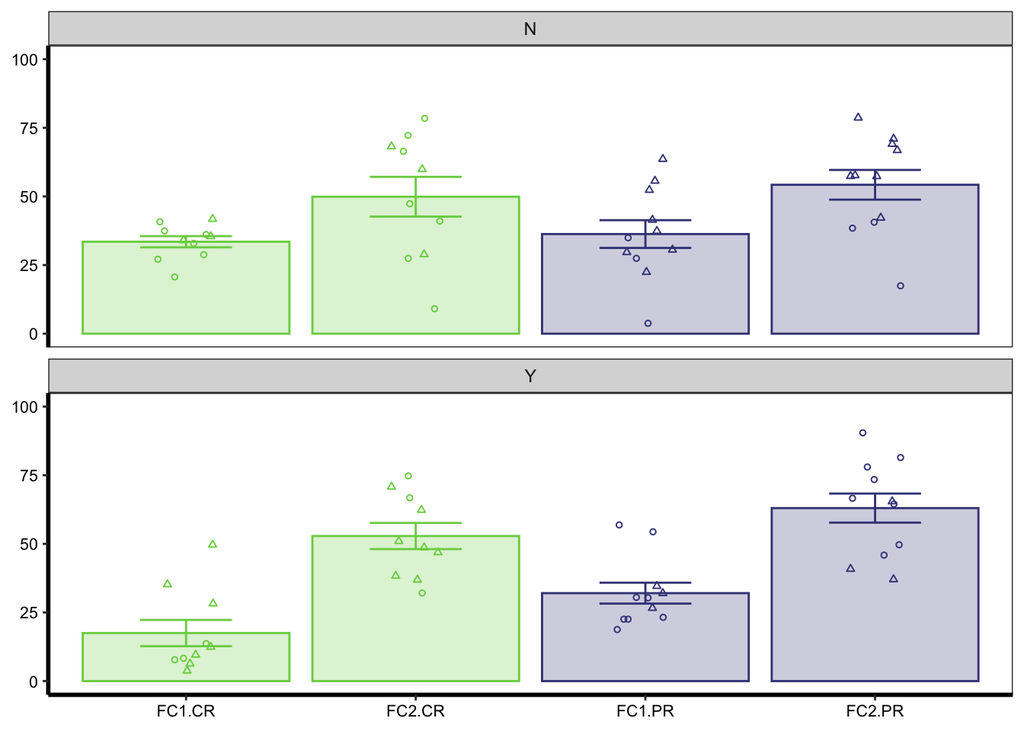

```r
Fig4.E2 <- ggplot(FC_ave_1.2,
  aes(x=interaction(Exp_Type, Contingency),
      y=group_mean_freezing,
      group = Contingency, fill= Contingency, color=Contingency)) +
  scale_color_viridis_d(begin=0.8, end=0.2) +
  scale_fill_viridis_d(begin=0.8, end=0.2) +
   facet_wrap(~IPE, ncol=1) +
  geom_errorbar(aes(ymin = group_mean_freezing-se, ymax = group_mean_freezing+se), width=0.4) +
  geom_bar(stat="identity", alpha=0.25) +
  geom_point(
    data=FC_id_1.2,
    aes(x=interaction(Exp_Type, Contingency), y=mean_freezing, shape=Sex),position = position_jitterdodge(jitter.height=0, jitter.width=0.25, dodge.width = 0.8), size=1) +
  scale_shape(solid = FALSE) +
   # scale_x_discrete(limits=c("FC1.100","FC2.100", "FC1.050", "FC2.050"),
   #                  labels= c("FC1", "FC2", "FC1", "FC2")) +
  ylim(0,100) +
  theme_bw() +
  theme(legend.position = "none",
        # strip.background = element_blank(),
        # strip.text = element_blank(),
        plot.background = element_blank(),
        axis.title.x = element_blank(),
        axis.title.y = element_blank(),
        plot.title = element_blank(),
        panel.grid.major = element_blank(),
        panel.grid.minor = element_blank(),
        axis.text.x = element_text(size = 8, color="black"),
        axis.text.y = element_text(size = 8, color="black"),
        axis.line.x = element_line(color="black", linewidth = 1),
        axis.line.y = element_line(color="black", linewidth = 1))+
  labs(
    x = "CS Time",
    y = "% Time Freezing")

Fig4.E2
```

```r
# ggsave("Fig4E2.pdf", plot = Fig4.E2, width = 1, height = 2, units = "in")
```

### E2 - Stats

```r
m4e2 <- FC_id_1.2 %>%
  aov_ez(id = "id",
         dv = "mean_freezing",
         between = c("Contingency", "IPE"),
         within = c("Exp_Type"),
         data = .)
```

```
## Converting to factor: Contingency, IPE
```

```
## Contrasts set to contr.sum for the following variables: Contingency, IPE
```

```r
#ANOVA table
nice_m4e2  <-nice(m4e2)
kable(nice_m4e2, caption = '<b>Figure 4.E2: Main FX</b>') %>%
  kable_styling(bootstrap_options = "striped", full_width = F, position = "left")
```

**Figure 4.E2: Main FX**

| Effect | df | MSE | F | ges | p.value |
| --- | --- | --- | --- | --- | --- |
| Contingency | 1, 38 | 348.42 | 3.82 + | .063 | .058 |
| IPE | 1, 38 | 348.42 | 0.27 | .005 | .605 |
| Contingency:IPE | 1, 38 | 348.42 | 1.16 | .020 | .288 |
| Exp_Type | 1, 38 | 175.29 | 75.75 *** | .400 | <.001 |
| Contingency:Exp_Type | 1, 38 | 175.29 | 0.06 | <.001 | .809 |
| IPE:Exp_Type | 1, 38 | 175.29 | 7.65 ** | .063 | .009 |
| Contingency:IPE:Exp_Type | 1, 38 | 175.29 | 0.26 | .002 | .612 |

```r
#Post-hoc analyses
n4e2 <- emmeans(m4e2, ~ IPE * Exp_Type)
n4e2_pairs<- pairs(n4e2, simple="each")
kable(n4e2_pairs[1], caption = '<b>Figure 4.E2: Simple contrasts for IPE</b>')
```

**Figure 4.E2: Simple contrasts for IPE**

| contrast | Exp_Type | estimate | SE | df | t.ratio | p.value |
| --- | --- | --- | --- | --- | --- | --- |
| N - Y | FC1 | 10.129030 | 4.14483 | 38 | 2.443775 | 0.0192886 |
| N - Y | FC2 | -5.869424 | 5.72808 | 38 | -1.024676 | 0.3119953 |

```r
kable(n4e2_pairs[2], caption = '<b>Figure 4.E2: Simple contrasts for FC Session</b>')
```

**Figure 4.E2: Simple contrasts for FC Session**

| contrast | IPE | estimate | SE | df | t.ratio | p.value |
| --- | --- | --- | --- | --- | --- | --- |
| FC1 - FC2 | N | -17.17403 | 4.090466 | 38 | -4.198551 | 0.000156 |
| FC1 - FC2 | Y | -33.17248 | 4.090466 | 38 | -8.109708 | 0.000000 |

## F. Within-Session Extinction

### F - Dataframe

```r
EXT_bin_id_1 <- df %>%
  filter(str_detect(Exp_Type, "E"),
         str_detect(Experiment, "ER|IPE", negate = TRUE)) %>%
  group_by(id, Sex, IPE, Contingency, Bin) %>%
  summarize(mean_freezing=mean(Pct.Component.Time.Freezing), n=n(),
            se=sd(Pct.Component.Time.Freezing/sqrt(n())))
EXT_bin_ave_1 <- EXT_bin_id_1 %>%
  group_by(Bin, IPE, Contingency) %>%
  summarize(group_mean_freezing=mean(mean_freezing), n=n(),
            se=sd(mean_freezing/sqrt(n())))
EXT_bin_ave_1$Bin <- factor(EXT_bin_ave_1$Bin, levels = c("Pre", "1", "2", "3", "4", "Post"))
```

### F - Graph

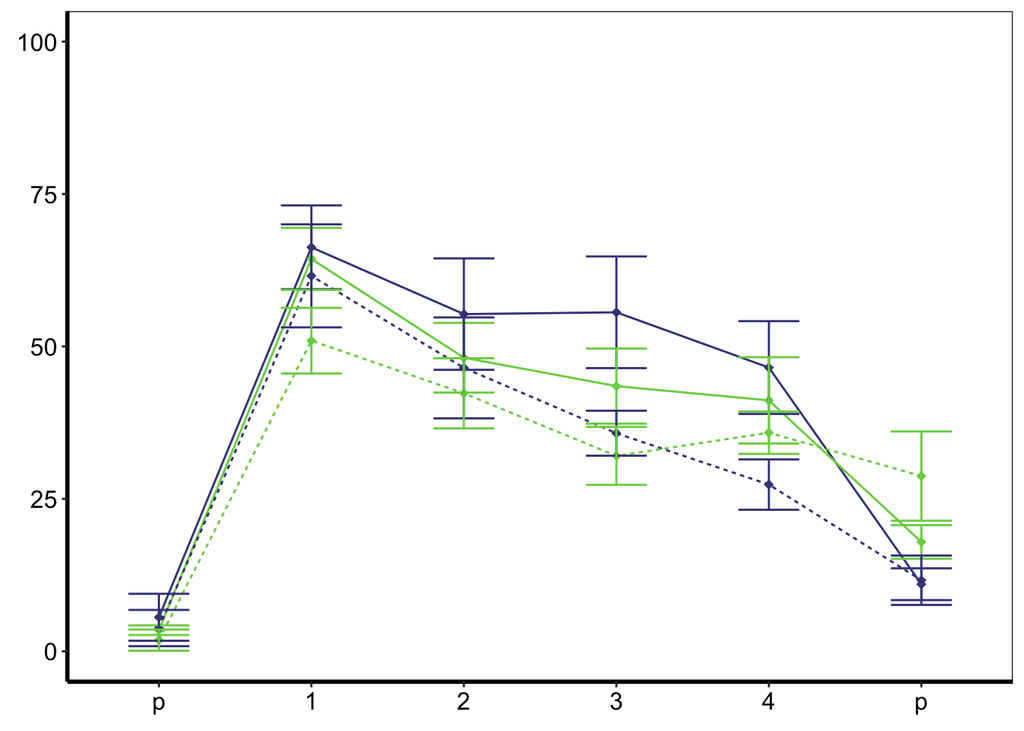

```r
Fig4.F <-
  ggplot(
  data = subset(EXT_bin_ave_1, !is.na(Bin)),
  aes(x=interaction(Bin),
      y=group_mean_freezing,
      group = interaction(Contingency, IPE), color= Contingency, fill=Contingency, linetype=IPE)) +
  scale_color_viridis_d(begin=0.2, end=0.8) +
  scale_fill_viridis_d(begin=0.2, end=0.8) +
  # facet_wrap(~IPE) +
  geom_line() +
  geom_point(shape=18, size=2) +
  scale_shape(solid = FALSE) +
  geom_errorbar(aes(ymin = group_mean_freezing-se, ymax = group_mean_freezing+se), width=0.4, linetype=1) +
  scale_x_discrete(limits=c("Pre", "1", "2", "3", "4", "Post"),
                   labels=c("p", "1", "2", "3", "4", "p")) +
  ylim(0,100) +
  labs(x = "Bin", y = "% Time Freezing") +
  theme_bw() +
    theme(
        legend.position = "none",
        strip.background = element_blank(),
        strip.text = element_blank(),
        plot.background = element_blank(),
        plot.title = element_text(size = 18,face="bold.italic", hjust=0.5),
        panel.grid.major = element_blank(),
        panel.grid.minor = element_blank(),
        axis.text.x = element_text(size = 12, color="black"),
        axis.text.y = element_text(size = 12, color="black"),
        axis.title.x = element_text(size = 0, face= "bold"),
        axis.title.y = element_text(size = 0, face="bold"),
        axis.line.x = element_line(color="black", linewidth = 1),
        axis.line.y = element_line(color="black", linewidth = 1))

Fig4.F
```

```r
 ggsave("Fig4.F.pdf", plot = Fig4.F, width = 1.25, height = 2, units = "in")
```

### F - Stats

```r
#FE1 - Mean freezing analysis
m4F1<- EXT_bin_id_1 %>%
  filter(str_detect(Bin, "Pre|Post", negate = TRUE)) %>%
  aov_ez(id = "id",
         dv = "mean_freezing",
         between = c("Contingency", "IPE"),
         within = c("Bin"),
         data = .)
```

```
## Converting to factor: Contingency, IPE
```

```
## Contrasts set to contr.sum for the following variables: Contingency, IPE
```

```r
##ANOVA table
nice_m4F1 <-nice(m4F1)
kable(nice_m4F1, caption = '<b>Figure 4.F1: Main FX</b>') %>%
  kable_styling(bootstrap_options = "striped", full_width = F, position = "left")
```

**Figure 4.F1: Main FX**

| Effect | df | MSE | F | ges | p.value |
| --- | --- | --- | --- | --- | --- |
| Contingency | 1, 32 | 845.53 | 0.85 | .015 | .365 |
| IPE | 1, 32 | 845.53 | 4.96 * | .085 | .033 |
| Contingency:IPE | 1, 32 | 845.53 | 0.17 | .003 | .680 |
| Bin | 2.67, 85.53 | 214.32 | 18.23 *** | .187 | <.001 |
| Contingency:Bin | 2.67, 85.53 | 214.32 | 0.79 | .010 | .490 |
| IPE:Bin | 2.67, 85.53 | 214.32 | 0.60 | .008 | .596 |
| Contingency:IPE:Bin | 2.67, 85.53 | 214.32 | 1.05 | .013 | .371 |

```r
##Post-hoc analyses
n4e1 <- emmeans(m4F1, ~ Bin)
n4e1_pairs<- pairs(n4e1, simple="each")

##Simple contrasts for Bin
kable(n4e1_pairs[], caption = '<b>Figure 4.D1-E1: Simple Contrasts by CS bin</b>')
```

| contrast | estimate | SE | df | t.ratio | p.value |
| --- | --- | --- | --- | --- | --- |
| X1 - X2 | 12.725660 | 2.910135 | 32 | 4.372876 | 0.0006716 |
| X1 - X3 | 19.060595 | 3.843294 | 32 | 4.959442 | 0.0001264 |
| X1 - X4 | 23.068171 | 3.603750 | 32 | 6.401157 | 0.0000020 |
| X2 - X3 | 6.334935 | 3.477184 | 32 | 1.821858 | 0.2820092 |
| X2 - X4 | 10.342511 | 3.018578 | 32 | 3.426286 | 0.0087627 |
| X3 - X4 | 4.007576 | 3.086570 | 32 | 1.298391 | 0.5706331 |